# 簡単な分析の実行例（Python編）

サンプルデータを読み込んで、散布図を書いてみよう！</br> （『[RとPythonで学ぶ実践的データサイエンス&機械学習](https://www.amazon.co.jp/dp/429710508X/ref=cm_sw_em_r_mt_dp_hXISFbNZQVC16)』より抜粋 p.95）

**Step1** 必要なライブラリを読み込む

```python
import pandas as pd
import matplotlib.pyplot as plt
```

**Step2** CSVファイルを読み込んでデータフレームに格納

```python
DF = pd.read_csv("https://raw.githubusercontent.com/mkato-riken/test/main/sample.csv")
```

**Step3** 先頭の６行を確認

```python
DF.head(6)
```

|  | varA | varB |
| --- | --- | --- |
| 0 | 1.092327 | 0.701387 |
| 1 | -0.212361 | 0.109707 |
| 2 | 0.850456 | 0.278144 |
| 3 | 0.969198 | 1.292435 |
| 4 | 2.596218 | 0.948212 |
| 5 | -0.508290 | -0.648164 |

**Step４** データ型と行数、列数を確認

```python
type(DF)
```

```
pandas.core.frame.DataFrame
```

```python
DF.shape
```

```
(200, 2)
```

**Step5** 平均値、最大値、最小値などを確認

```python
DF.describe()
```

|  | varA | varB |
| --- | --- | --- |
| count | 200.000000 | 200.000000 |
| mean | 0.025771 | 0.037083 |
| std | 1.006850 | 1.029864 |
| min | -2.801946 | -3.364918 |
| 25% | -0.544375 | -0.759240 |
| 50% | 0.084723 | 0.108739 |
| 75% | 0.710630 | 0.770033 |
| max | 2.596218 | 2.294457 |

**Step6** varAとvarBをそれぞれ２乗して足した値が１未満かどうかを判定（判定結果を id に入れる）

```python
id = DF['varA']**2 + DF['varB']**2 < 1
```

```python
id
```

```
0      False
1       True
2       True
3      False
4      False
       ...
195     True
196     True
197    False
198    False
199     True
Length: 200, dtype: bool
```

**Step7** IDという名称の列を作り "steelblue"という色の名称を入れる

```python
DF["ID"] = "steelblue"
```

**Step8** idの値がTRUEであるケース（行）だけ、IDの値を"darkblue"に置き換える

```python
DF.loc[id==True, "ID"] = "darkblue"
```

**Step9** IDの値について頻度を計算

```python
DF["ID"].value_counts()
```

```
steelblue    108
darkblue      92
Name: ID, dtype: int64
```

**Step10** 散布図を描く（横軸に用いる変数：varA 縦軸に用いる変数：varB 色の名称：ID)

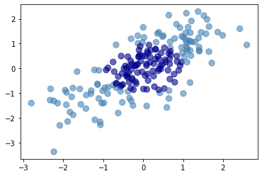

```python
plt.scatter(DF["varA"], DF["varB"],
            c=DF["ID"], alpha=0.6, s=70)
plt.show()
```

### 可視化ライブラリ：seabornを使ってみよう！

**seabornの長所：** </br>

- matplotlibと比べて見た目が洗練されている
- matplotlibと比べて少ないコードで図が描ける

```python
import seaborn as sns
```

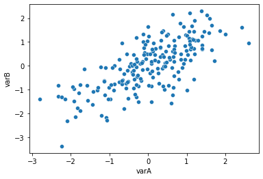

```python
sns.scatterplot(x='varA', y='varB', data=DF)
plt.show()
```